# Linear Regression

The following figure shows three data points and the best fit line: y = 3x + 2.

The x-coordinate, or “x”, is our independent variable and the y-coordinate, or “y”, is our dependent variable.

What is the baseline prediction?

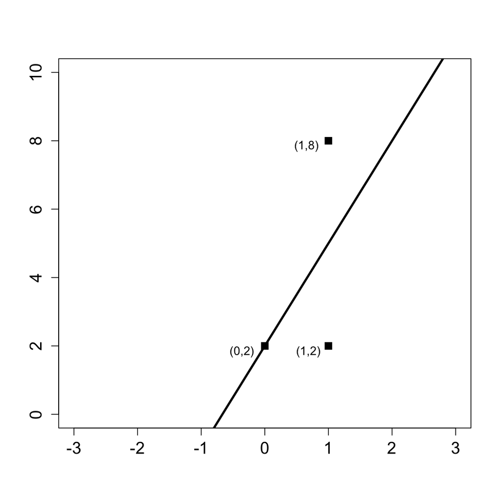

**Baseline model** - Is when all of the independent variables are equal to zero. We are only concerned about the dependent variables. We have 3 dependent variables.

```r
(2+2+8)/3
```

```
[1] 4
```

What is the Sum of Squared Errors (SSE) ?

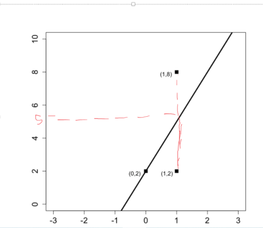

Actual y value - predicted y value

```r
(2-2)^2 + (2-5)^2 + (8-5)^2
```

[output not shown]

What is the Total Sum of Squares (SST) ?

actual y values - predicted_baseline_y value

baseline value was 4

```r
(2-4)^2 + (2-4)^2 +(8-4)^2
```

```
[1] 24
```

What is the R² of the model? 1- (SSE/SST)

```r
1 - (18/24)
```

```
[1] 0.25
```

In R, use the dataset wine.csv to create a linear regression model to predict Price using HarvestRain and WinterRain as independent variables. Using the summary output of this model, answer the following questions:

What is the “Multiple R-squared” value of your model?

```r
model <- lm(Price ~ HarvestRain + WinterRain, data=wine)
summary(model)
```

```
Call:
lm(formula = Price ~ HarvestRain + WinterRain, data = wine)

Residuals:
    Min      1Q  Median      3Q     Max
-1.0933 -0.3222 -0.1012  0.3871  1.1877

Coefficients:
              Estimate Std. Error t value Pr(>|t|)
(Intercept)  7.865e+00  6.616e-01  11.888 4.76e-11 ***
HarvestRain -4.971e-03  1.601e-03  -3.105  0.00516 **
WinterRain  -9.848e-05  9.007e-04  -0.109  0.91392
---
Signif. codes:  0 ‘***’ 0.001 ‘**’ 0.01 ‘*’ 0.05 ‘.’ 0.1 ‘ ’ 1

Residual standard error: 0.5611 on 22 degrees of freedom
Multiple R-squared:  0.3177,    Adjusted R-squared:  0.2557
F-statistic: 5.122 on 2 and 22 DF,  p-value: 0.01492
```

Using the data set wine.csv, what is the correlation between HarvestRain and WinterRain?

```r
cor(wine$HarvestRain,wine$WinterRain)
```

```
[1] -0.2754409
```

```r
1 - (18/24)
```

[output not shown]

```r
1 - (18/24)
```

[output not shown]